# HW01

caojilin

9/5/2018

#### Problem 1d)

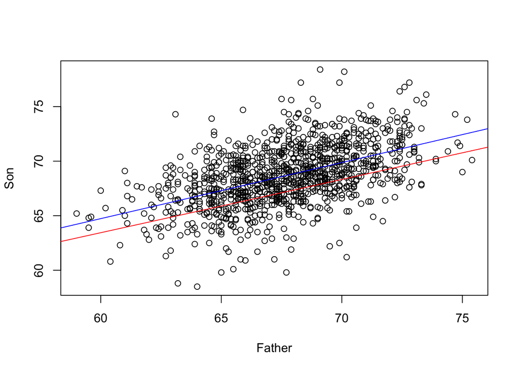

```r
dat = read.table("PearsonHeightData.txt", header = T)
lmod1 = lm(Son ~ Father, data = dat)
lmod2 = lm(Father ~ Son, data = dat)
plot(Son ~ Father, data = dat)
abline(lmod1, col = "blue")
abline(lmod2, col = "red")
```

#### Problem 5

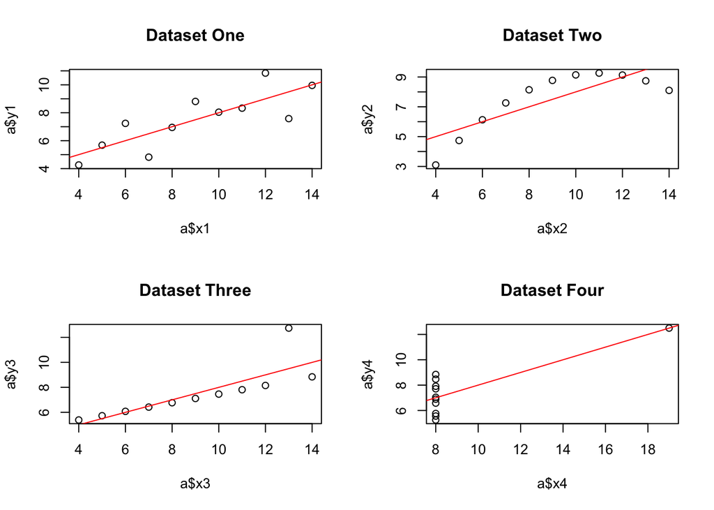

```r
library(datasets)
a <- anscombe
par(mfrow=c(2,2))


lm1 = lm(a$y1 ~ a$x1)

lm2 = lm(a$y2 ~ a$x2)

lm3 = lm(a$y3 ~ a$x3)

lm4 = lm(a$y4 ~ a$x4)

plot(a$x1,a$y1, main=paste("Dataset One"))
abline(lm1,col="red")
plot(a$x2,a$y2, main=paste("Dataset Two"))
abline(lm2,col="red")
plot(a$x3,a$y3, main=paste("Dataset Three"))
abline(lm3,col="red")
plot(a$x4,a$y4, main=paste("Dataset Four"))
abline(lm4,col="red")
```

dataset 1, and 3 make sense. Although dataset 3 has a outlier, it doesn’t matter.  
dataset 2 looks like a parabola, linear model is not accurate as dataset gets larger, but it’s ok for small dataset like this.  
dataset 4 doesn’t make sense because most of the data are clustered on the line x = 8

predictions are:

```r
lm1$coefficients[1] + 10 * lm1$coefficients[2]
```

```
## (Intercept)
##       8.001
```

```r
lm2$coefficients[1] + 10 * lm2$coefficients[2]
```

```
## (Intercept)
##    8.000909
```

```r
lm3$coefficients[1] + 10 * lm3$coefficients[2]
```

```
## (Intercept)
##    7.999727
```

```r
lm4$coefficients[1] + 10 * lm4$coefficients[2]
```

```
## (Intercept)
##    8.000818
```

again, predictions for dataset 1,2,3 are close to real data values. So they make sense. but dataset 4 doesn’t make sense.

#### Problem 7

### a)

we assume simple linear regression model for
$$(x_1,y_1),(x_2,y_2)\dots(x_n,y_n)$$
to be
$$y_i = \beta_0 + \beta_1 x_1 + e_i$$
where
$$\mathop{\mathbb{E}}(e_i\mid X_i) = 0$$
That means we have to make sure
$$\mathop{\mathbb{E}}(e_i\mid X_i) = 0$$
in order to assume a linear model.
To verify that: for
$$x_i<=65$$
$$y_i$$
can be wirrten as
$$y_i = N(\beta_0 +\beta_1 x_i,25) + N(0,25)$$
where
$$e_i = N(0,25)$$
this satisfies that
$$\mathop{\mathbb{E}}(e_i\mid X_i) = 0$$
similarly, for
$$65<x_i<=70$$
,
$$y_i = \beta_0 + \beta_1 x_i + e_i$$
where
$$e_i = 10T_i$$
whose mean is 0
for
$$x_i > 70$$
,
$$y_i = \beta_0 + \beta_1 x_i + e_i$$
where
$$e_i =U_i$$
, and
$$\mathop{\mathbb{E}}(U_i) = 0$$
Therefore, the condition
$$\mathop{\mathbb{E}}(e_i\mid X_i) = 0$$
for simple linear regression model is satisfied. Since we have proved in the class and in the homework that lease square estimators are unbiased. we can conclude that
$$\hat{\beta_0}$$
and
$$\hat{\beta_1}$$
are unbiased.

### b)

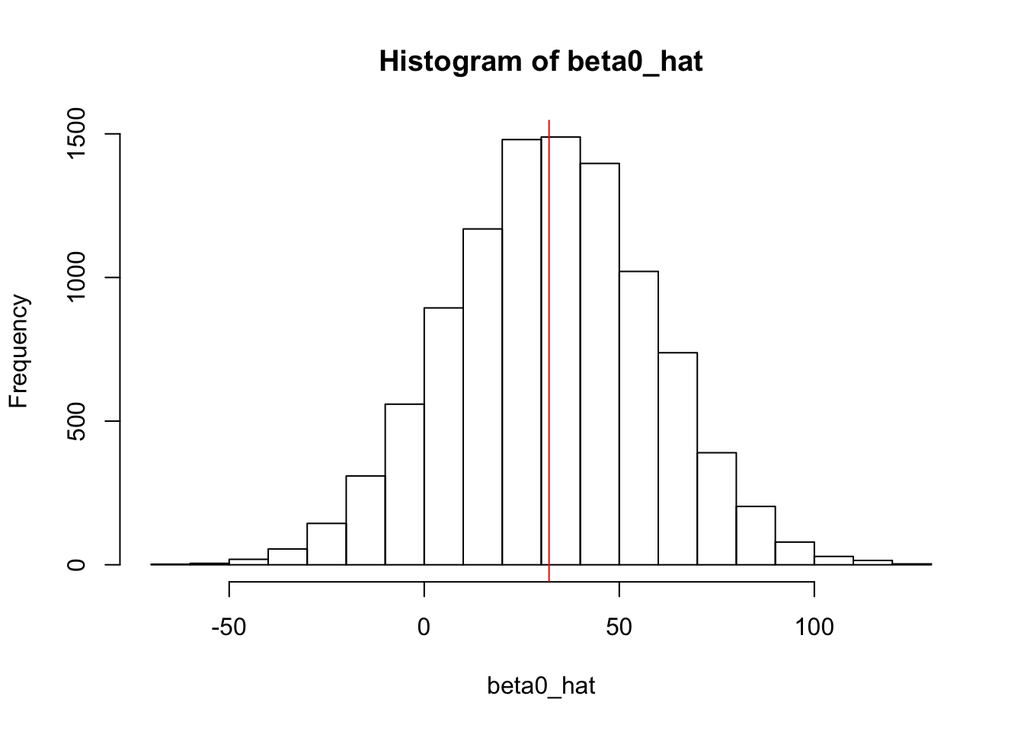

```r
M = 1:10000

samp = function(){
  x = seq(59, 76, length.out = 100)
  x1=x[x<=65]
  y1 = rnorm(length(x1),mean = 32+0.5*x1,sd = 25)
  x2=x[x>65 & x<=70]
  y2 = 32+0.5*x2+10*rt(n = length(x2),df = 3)
  x3=x[x>70]
  y3=32+0.5*x3+runif(length(x3),min = -8,max = 8)
  y = c(y1,y2,y3)
  return(list(x,y))
}
beta0_hat = c()
beta1_hat = c()
sd_beta0 = c()
sd_beta1 = c()

for (i in M) {
  sample = samp()
  x = sample[[1]]
  y = sample[[2]]
  lmod = lm(y ~ x)
  beta0_hat = c(beta0_hat, lmod$coefficients[1])
  beta1_hat = c(beta1_hat, lmod$coefficients[2])
  sd_beta0 = c(sd_beta0,summary(lmod)$coefficients[3])
  sd_beta1 = c(sd_beta1,summary(lmod)$coefficients[4])

}

hist(beta0_hat)
abline(v=32,col="red")
```

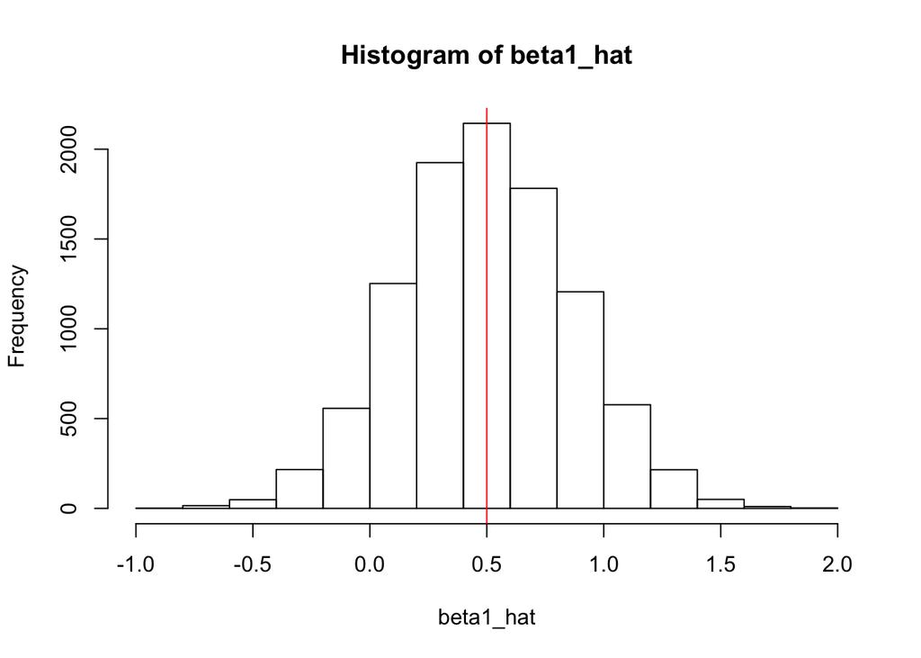

```r
hist(beta1_hat)
abline(v=0.5,col="red")
```

```r
#bias of beta 0
sum(beta0_hat -32)/10000
```

```
## [1] 0.2965467
```

```r
#bias of beta 1
sum(beta1_hat -0.5)/10000
```

```
## [1] -0.004216398
```

From histogram, the estimates of the bias are close to 0 and we found that the center for both graph are close to real
$$\beta_0=32$$
and
$$\beta_1=0.5$$
This verifies unbiasedness

### c)

homoskedasticity means that same variance of the errors,
$$Var(e_i \mid X) = \sigma^2$$
for each i. However, in this problem, we see that
$$Var(e_i \mid X) = \sigma^2$$
are not same for each i. Thus, homoskedasticity is not valid here.

### d)

we would like to check unbiasedness of
$$\mathop{\mathbb{E}}(\hat{Var(\hat{\beta})}) = Var(\hat{\beta})$$

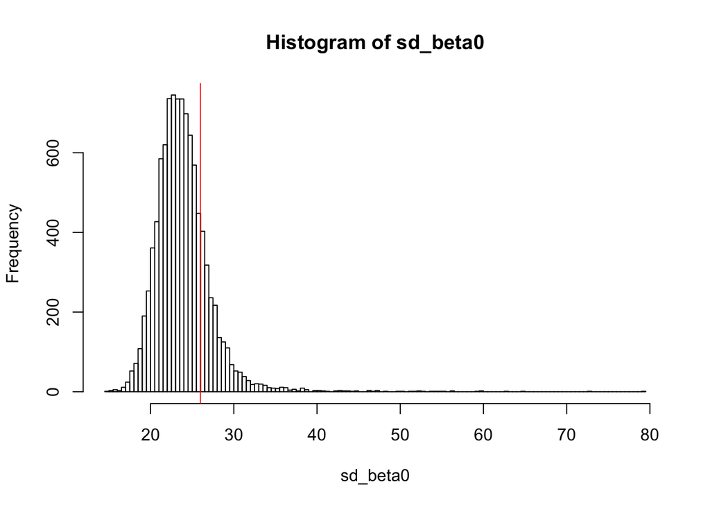

```r
sd0 = sd(beta0_hat)
sd1 = sd(beta1_hat)
hist(sd_beta0,breaks = 100)
abline(v=sd0,col="red")
```

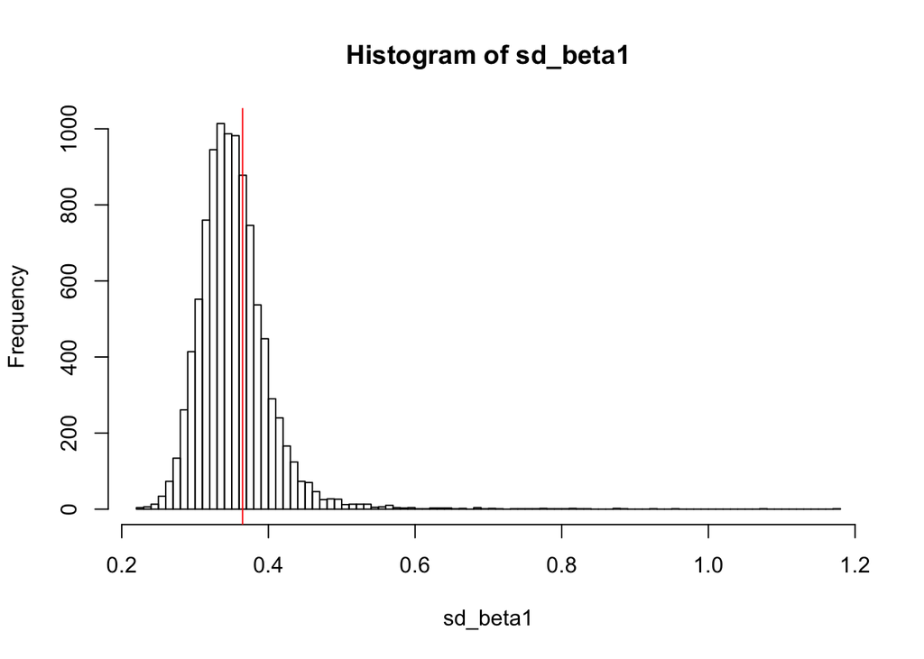

```r
hist(sd_beta1,breaks=100)
abline(v=sd1,col="red")
```

As we see from histograms, the centers are not close to sd0 and sd1, meaning that
$$\mathop{\mathbb{E}}(\hat{Var(\hat{\beta})}) \neq Var(\hat{\beta})$$
this verifies that homoskedasticity is not valid